# Part I - (PISA Data)

## Introduction

> Since 2000, the OECD has attempted to evaluate the knowledge and skills of 15-year olds across the world through its Pisa test. More than 510,000 students in 65 economies took part in the latest test, which covered maths, reading and science, with the main focus on maths - which the OECD state is a "strong predictor of participation in post-secondary education and future success." The triennial results provide a wealth of data - from which countries are making the biggest improvements in education ranking to how the gender gap varies by subject. We've picked out some key figures from the report:

> **What PISA Measures**: PISA’s goal is to assess students’ preparation for the challenges of life as young adults. PISA assesses the application of knowledge in mathematics, science, and reading literacy to problems within a real-life context (OECD 1999). PISA does not focus explicitly on curricular outcomes and uses the term “literacy” in each subject area to indicate its broad focus on the application of knowledge and skills. For example, when assessing mathematics, PISA examines how well 15-year-old students can understand, use, and reflect on mathematics for a variety of real-life problems and settings that they may not encounter in the classroom. Scores on the PISA scales represent skill levels along a continuum of literacy skills.  
> Each PISA data collection cycle assesses one of the three core subject areas in depth (considered the major subject area), although all three core subjects are assessed in each cycle (the other two subjects are considered minor subject areas for that assessment year). Assessing all three subjects every 3 years allows countries to have a consistent source of achievement data in each of the three subjects while rotating one area as the primary focus over the years. Mathematics was the major subject area in 2012, as it was in 2003, since each subject is a major subject area once every three cycles. In 2012, mathematics, science, and reading literacy were assessed primarily through a paper-and-pencil assessment, and problem solving was administered via a computer-based assessment. In addition to these core assessments, education systems could participate in optional paper-based financial literacy and computer-based mathematics and reading assessments.

## Preliminary Wrangling

```python
# import all packages and set plots to be embedded inline
import numpy as np
import pandas as pd
import matplotlib.pyplot as plt
from matplotlib.ticker import FuncFormatter
import seaborn as sb

%matplotlib inline

# suppress warnings from final output
import warnings
warnings.simplefilter("ignore")

# Setup plot parameters
sb.set()
params = {
    'legend.fontsize': 'medium',
    'figure.figsize': (10, 6),
    'axes.labelsize': 'x-large',
    'axes.titlesize': 'xx-large',
    'xtick.labelsize': 'large',
    'ytick.labelsize': 'large'
}
plt.rcParams.update(params)
```

```python
# Load the dataset this may take a few minutes due to large volume of data (2.6 Gb)
df=pd.read_csv('pisa2012.csv',encoding='ISO-8859-1', low_memory=False, index_col=0)
```

```python
#Show the 5 first rows
df.head()
```

|  | CNT | SUBNATIO | STRATUM | OECD | NC | SCHOOLID | STIDSTD | ST01Q01 | ST02Q01 | ST03Q01 | ... | W_FSTR75 | W_FSTR76 | W_FSTR77 | W_FSTR78 | W_FSTR79 | W_FSTR80 | WVARSTRR | VAR_UNIT | SENWGT_STU | VER_STU |
| --- | --- | --- | --- | --- | --- | --- | --- | --- | --- | --- | --- | --- | --- | --- | --- | --- | --- | --- | --- | --- | --- |
| 1 | Albania | 80000 | ALB0006 | Non-OECD | Albania | 1 | 1 | 10 | 1.0 | 2 | ... | 13.7954 | 13.9235 | 13.1249 | 13.1249 | 4.3389 | 13.0829 | 19 | 1 | 0.2098 | 22NOV13 |
| 2 | Albania | 80000 | ALB0006 | Non-OECD | Albania | 1 | 2 | 10 | 1.0 | 2 | ... | 13.7954 | 13.9235 | 13.1249 | 13.1249 | 4.3389 | 13.0829 | 19 | 1 | 0.2098 | 22NOV13 |
| 3 | Albania | 80000 | ALB0006 | Non-OECD | Albania | 1 | 3 | 9 | 1.0 | 9 | ... | 12.7307 | 12.7307 | 12.7307 | 12.7307 | 4.2436 | 12.7307 | 19 | 1 | 0.1999 | 22NOV13 |
| 4 | Albania | 80000 | ALB0006 | Non-OECD | Albania | 1 | 4 | 9 | 1.0 | 8 | ... | 12.7307 | 12.7307 | 12.7307 | 12.7307 | 4.2436 | 12.7307 | 19 | 1 | 0.1999 | 22NOV13 |
| 5 | Albania | 80000 | ALB0006 | Non-OECD | Albania | 1 | 5 | 9 | 1.0 | 10 | ... | 12.7307 | 12.7307 | 12.7307 | 12.7307 | 4.2436 | 12.7307 | 19 | 1 | 0.1999 | 22NOV13 |

5 rows × 635 columns

```python
# show the shape of data frame
df.shape
```

```
(485490, 635)
```

The data contains 485490 rows and 635 columns , and columnns contains an uncomprehensive names, to better handle our works we should select only column only necessary for our analysis.To do that we shoulkd first load "isadict2012.csv" file that contains column code.

```python
#Load column name
df2=pd.read_csv('pisadict2012.csv', encoding='ISO-8859-1')
df2
```

|  | Unnamed: 0 | x |
| --- | --- | --- |
| 0 | CNT | Country code 3-character |
| 1 | SUBNATIO | Adjudicated sub-region code 7-digit code (3-di... |
| 2 | STRATUM | Stratum ID 7-character (cnt + region ID + orig... |
| 3 | OECD | OECD country |
| 4 | NC | National Centre 6-digit Code |
| 5 | SCHOOLID | School ID 7-digit (region ID + stratum ID + 3-... |
| 6 | STIDSTD | Student ID |
| 7 | ST01Q01 | International Grade |
| 8 | ST02Q01 | National Study Programme |
| 9 | ST03Q01 | Birth - Month |
| 10 | ST03Q02 | Birth -Year |
| 11 | ST04Q01 | Gender |
| 12 | ST05Q01 | Attend <ISCED 0> |
| 13 | ST06Q01 | Age at <ISCED 1> |
| 14 | ST07Q01 | Repeat - <ISCED 1> |
| 15 | ST07Q02 | Repeat - <ISCED 2> |
| 16 | ST07Q03 | Repeat - <ISCED 3> |
| 17 | ST08Q01 | Truancy - Late for School |
| 18 | ST09Q01 | Truancy - Skip whole school day |
| 19 | ST115Q01 | Truancy - Skip classes within school day |
| 20 | ST11Q01 | At Home - Mother |
| 21 | ST11Q02 | At Home - Father |
| 22 | ST11Q03 | At Home - Brothers |
| 23 | ST11Q04 | At Home - Sisters |
| 24 | ST11Q05 | At Home - Grandparents |
| 25 | ST11Q06 | At Home - Others |
| 26 | ST13Q01 | Mother<Highest Schooling> |
| 27 | ST14Q01 | Mother Qualifications - <ISCED level 6> |
| 28 | ST14Q02 | Mother Qualifications - <ISCED level 5A> |
| 29 | ST14Q03 | Mother Qualifications - <ISCED level 5B> |
| ... | ... | ... |
| 605 | W_FSTR55 | FINAL STUDENT REPLICATE BRR-FAY WEIGHT55 |
| 606 | W_FSTR56 | FINAL STUDENT REPLICATE BRR-FAY WEIGHT56 |
| 607 | W_FSTR57 | FINAL STUDENT REPLICATE BRR-FAY WEIGHT57 |
| 608 | W_FSTR58 | FINAL STUDENT REPLICATE BRR-FAY WEIGHT58 |
| 609 | W_FSTR59 | FINAL STUDENT REPLICATE BRR-FAY WEIGHT59 |
| 610 | W_FSTR60 | FINAL STUDENT REPLICATE BRR-FAY WEIGHT60 |
| 611 | W_FSTR61 | FINAL STUDENT REPLICATE BRR-FAY WEIGHT61 |
| 612 | W_FSTR62 | FINAL STUDENT REPLICATE BRR-FAY WEIGHT62 |
| 613 | W_FSTR63 | FINAL STUDENT REPLICATE BRR-FAY WEIGHT63 |
| 614 | W_FSTR64 | FINAL STUDENT REPLICATE BRR-FAY WEIGHT64 |
| 615 | W_FSTR65 | FINAL STUDENT REPLICATE BRR-FAY WEIGHT65 |
| 616 | W_FSTR66 | FINAL STUDENT REPLICATE BRR-FAY WEIGHT66 |
| 617 | W_FSTR67 | FINAL STUDENT REPLICATE BRR-FAY WEIGHT67 |
| 618 | W_FSTR68 | FINAL STUDENT REPLICATE BRR-FAY WEIGHT68 |
| 619 | W_FSTR69 | FINAL STUDENT REPLICATE BRR-FAY WEIGHT69 |
| 620 | W_FSTR70 | FINAL STUDENT REPLICATE BRR-FAY WEIGHT70 |
| 621 | W_FSTR71 | FINAL STUDENT REPLICATE BRR-FAY WEIGHT71 |
| 622 | W_FSTR72 | FINAL STUDENT REPLICATE BRR-FAY WEIGHT72 |
| 623 | W_FSTR73 | FINAL STUDENT REPLICATE BRR-FAY WEIGHT73 |
| 624 | W_FSTR74 | FINAL STUDENT REPLICATE BRR-FAY WEIGHT74 |
| 625 | W_FSTR75 | FINAL STUDENT REPLICATE BRR-FAY WEIGHT75 |
| 626 | W_FSTR76 | FINAL STUDENT REPLICATE BRR-FAY WEIGHT76 |
| 627 | W_FSTR77 | FINAL STUDENT REPLICATE BRR-FAY WEIGHT77 |
| 628 | W_FSTR78 | FINAL STUDENT REPLICATE BRR-FAY WEIGHT78 |
| 629 | W_FSTR79 | FINAL STUDENT REPLICATE BRR-FAY WEIGHT79 |
| 630 | W_FSTR80 | FINAL STUDENT REPLICATE BRR-FAY WEIGHT80 |
| 631 | WVARSTRR | RANDOMIZED FINAL VARIANCE STRATUM (1-80) |
| 632 | VAR_UNIT | RANDOMLY ASSIGNED VARIANCE UNIT |
| 633 | SENWGT_STU | Senate weight - sum of weight within the count... |
| 634 | VER_STU | Date of the database creation |

635 rows × 2 columns

```python
#Select only the columns that we will work with throw the creation of a diccionary
columns = [
    'CNT', 'OECD','ST04Q01', 'ST13Q01' ,'ST15Q01','ST17Q01', 'ST19Q01', 'ST27Q01','ST27Q03', 'ST28Q01',
    'IC01Q04','IC02Q04','ST49Q07','IMMIG', 'WEALTH', 'PV1MATH', 'PV2MATH','PV3MATH', 'PV4MATH', 'PV5MATH', 'PV1READ',
    'PV2READ', 'PV3READ', 'PV4READ', 'PV5READ', 'PV1SCIE', 'PV2SCIE', 'PV3SCIE', 'PV4SCIE', 'PV5SCIE'
]
```

```python
#Load the data using 'usecols' parameter to select columns needed
df_c=pd.read_csv('pisa2012.csv', encoding='ISO-8859-1', low_memory=False, usecols=columns)
df_c.head()
```

[output not shown]

```python
df_c.sample(20)
```

|  | CNT | OECD | ST04Q01 | ST13Q01 | ST15Q01 | ST17Q01 | ST19Q01 | ST27Q01 | ST27Q03 | ST28Q01 | ST49Q07 | IC01Q04 | IC02Q04 | IMMIG | WEALTH | PV1MATH | PV2MATH | PV3MATH | PV4MATH | PV5MATH | PV1READ | PV2READ | PV3READ | PV4READ | PV5READ | PV1SCIE | PV2SCIE | PV3SCIE | PV4SCIE | … |
| --- | --- | --- | --- | --- | --- | --- | --- | --- | --- | --- | --- | --- | --- | --- | --- | --- | --- | --- | --- | --- | --- | --- | --- | --- | --- | --- | --- | --- | --- | --- |
| 86284 | Canada | OECD | Male | <ISCED level 3A> | Working full-time <for pay> | <ISCED level 3A> | Working full-time <for pay> | Three or more | Three or more | 11-25 books | NaN | NaN | NaN | Native | -0.12 | 444.0801 | 407.4700 | 483.0270 | 419.9330 | 447.1958 | 501.4380 | 490.2108 | 495.8244 | 491.8147 | 537.5255 | 507.9634 | 369.0228 | 509.8284 | 407.2548 | … |
| 175520 | Estonia | OECD | Female | <ISCED level 2> | Working part-time <for pay> | <ISCED level 3B, 3C> | Working full-time <for pay> | Three or more | Three or more | 26-100 books | NaN | Yes, and I use it | Yes, but I dont use it | Native | 0.82 | 445.7937 | 416.9730 | 399.8364 | 406.0679 | 450.4674 | 449.9806 | 382.4643 | 346.7203 | 383.2586 | 393.5846 | 480.9213 | 429.6345 | 430.5670 | 436.1619 | … |
| 223609 | Indonesia | Non-OECD | Female | <ISCED level 2> | Other (e.g. home duties, retired) | <ISCED level 3A> | Working full-time <for pay> | Two | None | 11-25 books | NaN | NaN | NaN | Native | -2.75 | 452.8821 | 531.5548 | 561.9333 | 473.9134 | 483.2606 | 482.1502 | 549.6665 | 575.0845 | 533.7803 | 485.3274 | 547.0347 | 591.7941 | 562.8870 | 545.1697 | … |
| 452348 | Chinese Taipei | Non-OECD | Female | <ISCED level 3A> | Working full-time <for pay> | <ISCED level 3A> | Working full-time <for pay> | Three or more | Two | 11-25 books | NaN | Yes, and I use it | Yes, but I dont use it | Native | -0.43 | 408.2489 | 414.4804 | 417.5962 | 352.1654 | 352.1654 | 399.9391 | 421.3855 | 403.9106 | 368.1667 | 364.9894 | 417.5121 | 412.8497 | 380.2126 | 368.0903 | … |
| 50015 | Bulgaria | Non-OECD | Male | <ISCED level 3B, 3C> | Working full-time <for pay> | <ISCED level 3A> | Not working, but looking for a job | Three or more | Two | 11-25 books | Sometimes | NaN | NaN | Native | -0.04 | 416.9730 | 416.9730 | 480.0670 | 427.8782 | 459.0357 | 388.1232 | 376.8959 | 441.8535 | 408.1718 | 430.6262 | 450.0559 | 387.5793 | 433.2712 | 435.1361 | … |
| 427516 | Singapore | Non-OECD | Female | <ISCED level 3A> | Working full-time <for pay> | <ISCED level 3A> | Working full-time <for pay> | Three or more | Three or more | 26-100 books | NaN | Yes, and I use it | Yes, but I dont use it | First-Generation | 0.55 | 758.8487 | 744.0489 | 762.7434 | 761.9645 | 727.6912 | 718.1397 | 697.4877 | 707.8137 | 680.0128 | 694.3104 | 678.3290 | 695.1138 | 718.4260 | 699.7762 | … |
| 478028 | United States of America | OECD | Male | <ISCED level 3A> | Working full-time <for pay> | <ISCED level 3A> | Working full-time <for pay> | Three or more | None | 11-25 books | Never or rarely | NaN | NaN | Native | -0.71 | 560.6870 | 549.7819 | 545.1083 | 566.9185 | 599.6339 | 576.5803 | 593.4211 | 558.1355 | 548.5122 | 588.6094 | 596.9228 | 617.4375 | 575.4756 | 585.7329 | … |
| 222713 | Indonesia | Non-OECD | Female | <ISCED level 1> | Other (e.g. home duties, retired) | <ISCED level 1> | Working part-time <for pay> | Three or more | None | 26-100 books | Sometimes | NaN | NaN | Native | -2.41 | 313.3744 | 320.3848 | 265.0802 | 295.4588 | 262.7434 | 318.9195 | 310.1820 | 365.7838 | 360.2236 | 280.7926 | 354.1029 | 289.7613 | 311.2085 | 277.6389 | … |
| 220194 | Hungary | OECD | Female | <ISCED level 2> | Working full-time <for pay> | <ISCED level 3B, 3C> | Working full-time <for pay> | Three or more | Two | 201-500 books | Never or rarely | Yes, and I use it | Yes, but I dont use it | Native | 0.37 | 554.9229 | 523.7654 | 561.9333 | 522.9864 | 549.4703 | 588.5083 | 578.9766 | 592.4799 | 633.7840 | 599.6287 | 571.5591 | 547.3144 | 550.1119 | 541.7195 | … |
| 75200 | Canada | OECD | Female | <ISCED level 3A> | Working full-time <for pay> | <ISCED level 3A> | Working full-time <for pay> | Three or more | Two | 11-25 books | NaN | NaN | NaN | NaN | 0.44 | 371.7168 | 351.4644 | 342.8961 | 363.9274 | 445.7158 | 468.7263 | 464.7548 | 421.0677 | 418.6848 | 470.3150 | 441.4771 | 475.0466 | 411.6374 | 406.9750 | … |
| 484582 | Vietnam | Non-OECD | Female | <ISCED level 2> | Other (e.g. home duties, retired) | He did not complete <ISCED level 1> | Other (e.g. home duties, retired) | Two | None | 26-100 books | NaN | NaN | NaN | Native | -3.12 | 580.1605 | 552.1187 | 522.5191 | 587.9498 | 564.5817 | 543.3121 | 511.5397 | 519.4828 | 518.6885 | 579.0560 | 631.9843 | 540.6005 | 554.5878 | 545.2630 | … |
| 288353 | Kazakhstan | Non-OECD | Male | <ISCED level 3A> | Working full-time <for pay> | <ISCED level 2> | Working full-time <for pay> | Three or more | One | 26-100 books | NaN | NaN | NaN | Second-Generation | -1.73 | 431.9286 | 402.3290 | 372.7294 | 398.4343 | 408.5605 | 345.6201 | 378.4998 | 355.2434 | 347.2240 | 337.6006 | 369.0228 | 360.6304 | 335.4532 | 365.2928 | … |
| 194719 | United Kingdom | OECD | Female | <ISCED level 2> | Working full-time <for pay> | <ISCED level 3A> | Other (e.g. home duties, retired) | Three or more | One | 26-100 books | NaN | NaN | NaN | Native | 0.22 | 439.4843 | 426.2424 | 380.2851 | 448.8316 | 455.0631 | 456.0174 | 467.9320 | 388.5010 | 424.2450 | 437.7482 | 341.7009 | 405.1100 | 361.2831 | 396.7176 | … |
| 67035 | Brazil | Non-OECD | Male | <ISCED level 2> | Other (e.g. home duties, retired) | <ISCED level 3A> | Working full-time <for pay> | Three or more | None | 0-10 books | Never or rarely | NaN | NaN | Native | -1.93 | 352.3991 | 389.0092 | 385.8934 | 378.1041 | 374.9883 | 337.6006 | 393.7368 | 417.7951 | 310.3345 | 394.5387 | 364.6401 | 387.9523 | 428.9817 | 400.0746 | … |
| 376513 | Peru | Non-OECD | Male | <ISCED level 3A> | Other (e.g. home duties, retired) | <ISCED level 3A> | Working full-time <for pay> | Three or more | One | 11-25 books | Often | NaN | NaN | Native | 0.19 | 334.0162 | 333.2373 | 334.0162 | 358.1633 | 322.3321 | 348.0259 | 351.2337 | 342.4123 | 299.9092 | 344.8181 | 378.3476 | 395.1324 | 358.7654 | 380.2126 | … |
| 349667 | Montenegro | Non-OECD | Female | <ISCED level 3B, 3C> | Other (e.g. home duties, retired) | <ISCED level 3B, 3C> | Other (e.g. home duties, retired) | Three or more | One | 0-10 books | Never or rarely | NaN | NaN | Native | 0.65 | 324.2795 | 240.1542 | 330.5110 | 250.2804 | 315.7112 | 363.4008 | 264.1121 | 356.2520 | 322.8910 | 300.6503 | 413.7822 | 276.7065 | 340.1156 | 242.2044 | … |
| 306103 | Latvia | Non-OECD | Female | <ISCED level 2> | Working full-time <for pay> | <ISCED level 3B, 3C> | Working full-time <for pay> | Three or more | Two | 11-25 books | Never or rarely | No | Yes, but I dont use it | Native | -1.04 | 335.1067 | 319.5280 | 249.4236 | 289.9283 | 253.3183 | 391.6783 | 338.4595 | 304.3041 | 324.1619 | 270.9431 | 351.0257 | 337.9709 | 307.1988 | 325.8486 | … |
| 107580 | Chile | OECD | Female | <ISCED level 3A> | Other (e.g. home duties, retired) | <ISCED level 3A> | Working full-time <for pay> | Three or more | Three or more | 0-10 books | Never or rarely | Yes, and I use it | Yes, and I use it | Native | 0.03 | 374.2094 | 381.2198 | 417.0509 | 367.9779 | 413.9352 | 417.9699 | 476.7489 | 478.3375 | 430.6789 | 464.0399 | 457.8888 | 498.9183 | 463.4838 | 444.8340 | … |
| 19880 | Argentina | Non-OECD | Female | <ISCED level 3A> | Working full-time <for pay> | He did not complete <ISCED level 1> | Other (e.g. home duties, retired) | Three or more | None | 26-100 books | Never or rarely | NaN | NaN | Native | -0.95 | 231.5859 | 313.3744 | 210.5546 | 246.3857 | 264.3013 | 239.3296 | 305.2573 | 187.6994 | 310.8175 | 244.8898 | 187.4674 | 293.7710 | 203.3197 | 287.2436 | … |
| 76311 | Canada | OECD | Male | <ISCED level 3A> | Working part-time <for pay> | <ISCED level 3A> | Working full-time <for pay> | Three or more | Three or more | 26-100 books | Sometimes | NaN | NaN | Native | 2.90 | 526.6475 | 532.1000 | 553.9103 | 533.6579 | 556.2471 | 549.5547 | 551.1586 | 542.3372 | 569.6033 | 537.5255 | 483.7188 | 528.4782 | 528.4782 | 523.8157 | … |

```python
#View data frame dimensions
df_c.shape
```

```
(485490, 30)
```

So we reduced the number of column from 635 to 30 and will reduce it further inn next operations

```python
df_c.info()
```

```
<class 'pandas.core.frame.DataFrame'>
RangeIndex: 485490 entries, 0 to 485489
Data columns (total 30 columns):
 #   Column   Non-Null Count   Dtype
---  ------   --------------   -----
 0   CNT      485490 non-null  object
 1   OECD     485490 non-null  object
 2   ST04Q01  485490 non-null  object
 3   ST13Q01  457979 non-null  object
 4   ST15Q01  467751 non-null  object
 5   ST17Q01  443261 non-null  object
 6   ST19Q01  451410 non-null  object
 7   ST27Q01  477079 non-null  object
 8   ST27Q03  473459 non-null  object
 9   ST28Q01  473765 non-null  object
```

[output cut: 22 more lines]

```python
#Checing for duplicates
df_c.duplicated().sum()
```

```
0
```

### What is/are the main feature(s) of interest in your dataset?

> The main feature of interest in the dataset is to discover which factors affect the students' total scores in Maths, Reading and Science, in relationship with parents job, educations and acces to internet, book and genral wealth, immigration statue.

### What features in the dataset do you think will help support your investigation into your feature(s) of interest?

> Many variables will be examined to find which variable(s) affects the students' scores the most. These variables include gender, immigration status, the parents' job status and highest schooling, parents job, educations and acces to internet, book and genral wealth, immigration statue.

> We believe the features that will most influence the students' scores will be how econmics factors, the immigration status.

```python
df_c['CNT'].unique()
```

```
array(['Albania', 'United Arab Emirates', 'Argentina', 'Australia',
       'Austria', 'Belgium', 'Bulgaria', 'Brazil', 'Canada',
       'Switzerland', 'Chile', 'Colombia', 'Costa Rica', 'Czech Republic',
       'Germany', 'Denmark', 'Spain', 'Estonia', 'Finland', 'France',
       'United Kingdom', 'Greece', 'Hong Kong-China', 'Croatia',
       'Hungary', 'Indonesia', 'Ireland', 'Iceland', 'Israel', 'Italy',
       'Jordan', 'Japan', 'Kazakhstan', 'Korea', 'Liechtenstein',
       'Lithuania', 'Luxembourg', 'Latvia', 'Macao-China', 'Mexico',
       'Montenegro', 'Malaysia', 'Netherlands', 'Norway', 'New Zealand',
       'Peru', 'Poland', 'Portugal', 'Qatar', 'China-Shanghai',
       'Perm(Russian Federation)', 'Florida (USA)', 'Connecticut (USA)',
       'Massachusetts (USA)', 'Romania', 'Russian Federation',
       'Singapore', 'Serbia', 'Slovak Republic', 'Slovenia', 'Sweden',
       'Chinese Taipei', 'Thailand', 'Tunisia', 'Turkey', 'Uruguay',
       'United States of America', 'Vietnam'], dtype=object)
```

Although as we can see on "CNT" column, there is entries like 'China-Shanghai' and 'Florida (USA)' that represent cities not countries, we will keep these entries because it represent an educatif system or experience different from the main countries for example Shanghai in China is a city province to a more than 26 millions It is by itself bigger than most of the countries that are included in the PISA rankings, larger than all but two American states and equal in size to the total population of our 11 smallest states combined.

```python
# 'OECD' represent if coutries is a member of Organisation for Economic Co-operation and Development
df_c['OECD'].unique()
```

```
array(['Non-OECD', 'OECD'], dtype=object)
```

```python
#'ST04Q01' represent gender
df_c['ST04Q01'].unique()
```

```
array(['Female', 'Male'], dtype=object)
```

```python
# 'ST13Q01' and ST17Q01 reprersent the higheet level eduction for mother and father respectively
df_c['ST13Q01'].unique()
df_c['ST17Q01'].unique()
```

```
array(['<ISCED level 3A> ', '<ISCED level 3B, 3C> ', '<ISCED level 2> ',
       'He did not complete <ISCED level 1> ', nan, '<ISCED level 1> '],
      dtype=object)
```

```python
# 'ST15Q01' and 'ST19Q01' reprersent working stgatus for mother and father respectively
df_c['ST15Q01'].unique()
df_c['ST19Q01'].unique()
```

```
array(['Working part-time <for pay>', 'Working full-time <for pay> ',
       'Not working, but looking for a job',
       'Other (e.g. home duties, retired) ', nan], dtype=object)
```

```python
# 'ST27Q01','ST27Q03' represent respectively How many - cellular phones and How many - computers
df_c['ST27Q01'].unique()
df_c['ST27Q03'].unique()
```

```
array(['None', 'Three or more', 'Two', 'One', nan], dtype=object)
```

```python
# 'ST49Q07' Math Behaviour - Computer programming
#'IC01Q04' At Home - Internet connection
#'IC02Q04' At school - Internet connection
df_c['ST49Q07'].unique()
df_c['IC01Q04'].unique()
df_c['IC02Q04'].unique()
```

```
array([nan, 'Yes, and I use it', 'Yes, but I don\x92t use it', 'No'],
      dtype=object)
```

```python
#IMMIG stand for immmigration
df_c['IMMIG'].unique()
```

```
array(['Native', nan, 'Second-Generation', 'First-Generation'],
      dtype=object)
```

```python
#WEALTH
df_c['WEALTH'].describe()
```

```
count    479597.00000
mean         -0.33701
std           1.21530
min          -6.65000
25%          -1.04000
50%          -0.30000
75%           0.43000
max           3.25000
Name: WEALTH, dtype: float64
```

```python
#'PV1MATH', 'PV2MATH','PV3MATH', 'PV4MATH', 'PV5MATH' stand from mathematics scorers that need to be unified
#in a single column
df_c[['PV1MATH', 'PV2MATH','PV3MATH', 'PV4MATH', 'PV5MATH']].describe()
```

|  | PV1MATH | PV2MATH | PV3MATH | PV4MATH | PV5MATH |
| --- | --- | --- | --- | --- | --- |
| count | 485490.000000 | 485490.000000 | 485490.000000 | 485490.000000 | 485490.000000 |
| mean | 469.621653 | 469.648358 | 469.648930 | 469.641832 | 469.695396 |
| std | 103.265391 | 103.382077 | 103.407631 | 103.392286 | 103.419170 |
| min | 19.792800 | 6.473000 | 42.226200 | 24.622200 | 37.085200 |
| 25% | 395.318600 | 395.318600 | 395.240700 | 395.396500 | 395.240700 |
| 50% | 466.201900 | 466.124000 | 466.201900 | 466.279800 | 466.435600 |
| 75% | 541.057800 | 541.447300 | 541.291500 | 541.447300 | 541.447300 |
| max | 962.229300 | 957.010400 | 935.745400 | 943.456900 | 907.625800 |

```python
# 'PV1READ', 'PV2READ', 'PV3READ', 'PV4READ', 'PV5READ' stand fro reading score that we need to get the mean
#and out in one column
df_c[['PV1READ', 'PV2READ', 'PV3READ', 'PV4READ', 'PV5READ']].describe()
```

|  | PV1READ | PV2READ | PV3READ | PV4READ | PV5READ |
| --- | --- | --- | --- | --- | --- |
| count | 485490.000000 | 485490.000000 | 485490.000000 | 485490.000000 | 485490.000000 |
| mean | 472.004640 | 472.068052 | 472.022059 | 471.926562 | 472.013506 |
| std | 102.505523 | 102.626198 | 102.640489 | 102.576066 | 102.659989 |
| min | 0.083400 | 0.703500 | 0.703500 | 4.134400 | 2.307400 |
| 25% | 403.600700 | 403.360100 | 403.360100 | 403.354600 | 403.360100 |
| 50% | 475.455000 | 475.535200 | 475.455000 | 475.535200 | 475.535200 |
| 75% | 544.502500 | 544.503500 | 544.503500 | 544.502500 | 544.503500 |
| max | 904.802600 | 881.239200 | 884.447000 | 881.159000 | 901.608600 |

```python
# 'PV1SCIE', 'PV2SCIE', 'PV3SCIE', 'PV4SCIE', 'PV5SCIE' stand fro science score that we need to get the mean
#and out in one column
df_c[['PV1SCIE', 'PV2SCIE', 'PV3SCIE', 'PV4SCIE', 'PV5SCIE']].describe()
```

|  | PV1SCIE | PV2SCIE | PV3SCIE | PV4SCIE | PV5SCIE |
| --- | --- | --- | --- | --- | --- |
| count | 485490.000000 | 485490.000000 | 485490.000000 | 485490.00000 | 485490.000000 |
| mean | 475.769824 | 475.813674 | 475.851549 | 475.78524 | 475.820184 |
| std | 101.464426 | 101.514649 | 101.495072 | 101.51220 | 101.566347 |
| min | 2.648300 | 2.834800 | 11.879900 | 8.42970 | 17.754600 |
| 25% | 404.457300 | 404.457300 | 404.550500 | 404.45730 | 404.457300 |
| 50% | 475.699400 | 475.606100 | 475.699400 | 475.97910 | 475.885900 |
| 75% | 547.780700 | 547.873900 | 547.967200 | 547.78070 | 547.780700 |
| max | 903.338300 | 900.540800 | 867.624000 | 926.55730 | 880.958600 |

### Quality issues

- Incomprehensible column names
- Father and mother job status shoulb be also furtther simplified
- higheet level education for mother and father can be also simplified
- change OECD_country, gender, Mother_Schooling, Mother_Job ,Father_Schooling, Father_Job, cellular_phones, computers,books_at_home, computer_programming, At_Home_Internet_connection, At_school_Internet_connection, Immigration_status to categoeies types.

### Tidiness issues

- Combine plausible scores

```python
# Rename the columns to be more representable:

df_c = df_c.rename(columns={'CNT':'country', 'OECD':'OECD_country','ST04Q01':'Gender',
                            'ST13Q01':'Mother_Schooling' ,'ST15Q01':'Mother_Job',
                            'ST17Q01':'Father_Schooling', 'ST19Q01':'Father_Job',
                            'ST27Q01':'cellular_phones','ST27Q03':'computers',
                            'ST28Q01':'books_at_home','ST49Q07':'computer_programming',
                            'IC01Q04':'At_Home_Internet_connection',
                            'IC02Q04':'At_school_Internet_connection','IMMIG':'Immigration_status',
                            'WEALTH':'Family_wealth'})
```

```python
df_c.head()
```

|  | country | OECD_country | Gender | Mother_Schooling | Mother_Job | Father_Schooling | Father_Job | cellular_phones | computers | books_at_home | computer_programming | At_Home_Internet_connection | At_school_Internet_connection | Immigration_status | Family_wealth | PV1MATH | PV2MATH | PV3MATH | PV4MATH | PV5MATH | PV1READ | PV2READ | PV3READ | PV4READ | PV5READ | PV1SCIE | PV2SCIE | PV3SCIE | PV4SCIE | … |
| --- | --- | --- | --- | --- | --- | --- | --- | --- | --- | --- | --- | --- | --- | --- | --- | --- | --- | --- | --- | --- | --- | --- | --- | --- | --- | --- | --- | --- | --- | --- |
| 0 | Albania | Non-OECD | Female | <ISCED level 3A> | Other (e.g. home duties, retired) | <ISCED level 3A> | Working part-time <for pay> | Two | None | 0-10 books | Never or rarely | NaN | NaN | Native | -2.92 | 406.8469 | 376.4683 | 344.5319 | 321.1637 | 381.9209 | 249.5762 | 254.3420 | 406.8496 | 175.7053 | 218.5981 | 341.7009 | 408.8400 | 348.2283 | 367.8105 | … |
| 1 | Albania | Non-OECD | Female | <ISCED level 3A> | Working full-time <for pay> | <ISCED level 3A> | Working full-time <for pay> | Three or more | Three or more | 201-500 books | Never or rarely | NaN | NaN | Native | 0.69 | 486.1427 | 464.3325 | 453.4273 | 472.9008 | 476.0165 | 406.2936 | 349.8975 | 400.7334 | 369.7553 | 396.7618 | 548.9929 | 471.5964 | 471.5964 | 443.6218 | … |
| 2 | Albania | Non-OECD | Female | <ISCED level 3B, 3C> | Working full-time <for pay> | <ISCED level 3A> | Working full-time <for pay> | Three or more | Two | More than 500 books | Never or rarely | NaN | NaN | Native | -0.23 | 533.2684 | 481.0796 | 489.6479 | 490.4269 | 533.2684 | 401.2100 | 404.3872 | 387.7067 | 431.3938 | 401.2100 | 499.6643 | 428.7952 | 492.2044 | 512.7191 | … |
| 3 | Albania | Non-OECD | Female | <ISCED level 3B, 3C> | Working full-time <for pay> | <ISCED level 3A> | Working full-time <for pay> | Three or more | One | 11-25 books | NaN | NaN | NaN | Native | -1.17 | 412.2215 | 498.6836 | 415.3373 | 466.7472 | 454.2842 | 547.3630 | 481.4353 | 461.5776 | 425.0393 | 471.9036 | 438.6796 | 481.5740 | 448.9370 | 474.1141 | … |
| 4 | Albania | Non-OECD | Female | She did not complete <ISCED level 1> | Working part-time <for pay> | <ISCED level 3B, 3C> | Working part-time <for pay> | Two | Two | 101-200 books | Sometimes | NaN | NaN | Native | -1.17 | 381.9209 | 328.1742 | 403.7311 | 418.5309 | 395.1628 | 311.7707 | 141.7883 | 293.5015 | 272.8495 | 260.1405 | 361.5628 | 275.7740 | 372.7527 | 403.5248 | … |

```python
#Clean Mother_job data
df_c['Mother_Job']= df_c['Mother_Job'].replace(['Working full-time <for pay> ', 'Working part-time <for pay>',
                                                 'Not working, but looking for a job ',
                                                 'Other (e.g. home duties, retired) '],
                                                ['Full-time','Part-time','Looking','other'])
```

```python
df_c.Mother_Job.unique()
```

```
array(['other', 'Full-time', 'Part-time', 'Looking', nan], dtype=object)
```

```python
#Clean Father_job data
df_c['Father_Job']= df_c['Father_Job'].replace(['Working full-time <for pay> ', 'Working part-time <for pay>',
                                                 'Not working, but looking for a job',
                                                 'Other (e.g. home duties, retired) '],
                                                ['Full-time','Part-time','Looking','other'])
```

```python
df_c.Father_Job.unique()
```

```
array(['Part-time', 'Full-time', 'Looking', 'other', nan], dtype=object)
```

```python
#change Mother and fater job to categories
job_dtype = pd.api.types.CategoricalDtype(ordered = True, categories=['Other', 'Looking', 'Part-time', 'Full-time'])
df_c.loc[:,'Mother_Job'] = df_c.Mother_Job.astype(job_dtype)
df_c.loc[:,'Father_Job'] = df_c.Father_Job.astype(job_dtype)
```

```python
# Check that the categories changed

df_c['Mother_Job'].unique()
```

```
[NaN, 'Full-time', 'Part-time', 'Looking']
Categories (4, object): ['Other' < 'Looking' < 'Part-time' < 'Full-time']
```

```python
df_c['Father_Job'].unique()
```

```
['Part-time', 'Full-time', 'Looking', NaN]
Categories (4, object): ['Other' < 'Looking' < 'Part-time' < 'Full-time']
```

```python
#Simplify highest education for mother
df_c['Mother_Schooling']= df_c['Mother_Schooling'].replace(['<ISCED level 3A> ', '<ISCED level 3B, 3C> ',
                                                 '<ISCED level 2> ',
                                                 '<ISCED level 1> ', 'She did not complete <ISCED level 1> '],
                                                ['Level 3A','Level 3B or 3C','Level 2','Level 1','< Level 1'])
```

```python
df_c.Mother_Schooling.unique()
```

```
array(['Level 3A', 'Level 3B or 3C', '< Level 1', 'Level 2', 'Level 1',
       nan], dtype=object)
```

```python
#Simplify highest education for father
df_c['Father_Schooling']= df_c['Father_Schooling'].replace(['<ISCED level 3A> ', '<ISCED level 3B, 3C> ',
                                                 '<ISCED level 2> ',
                                                 '<ISCED level 1> ', 'He did not complete <ISCED level 1> '],
                                                ['Level 3A','Level 3B or 3C','Level 2','Level 1','< Level 1'])
```

```python
df_c.Father_Schooling.unique()
```

```
array(['Level 3A', 'Level 3B or 3C', 'Level 2', '< Level 1', nan,
       'Level 1'], dtype=object)
```

```python
#change Mother and fater job to categories
school_dtype = pd.api.types.CategoricalDtype(ordered = True, categories=['< Level 1', 'Level 1', 'Level 2',
                                                                      'Level 3A', 'Level 3B or 3C'])
df_c.loc[:,'Mother_Schooling'] = df_c.Mother_Schooling.astype(school_dtype)
df_c.loc[:,'Father_Schooling'] = df_c.Father_Schooling.astype(school_dtype)
```

```python
df_c.Mother_Schooling.unique()
```

```
['Level 3A', 'Level 3B or 3C', '< Level 1', 'Level 2', 'Level 1', NaN]
Categories (5, object): ['< Level 1' < 'Level 1' < 'Level 2' < 'Level 3A' < 'Level 3B or 3C']
```

```python
df_c.Father_Schooling.unique()
```

```
['Level 3A', 'Level 3B or 3C', 'Level 2', '< Level 1', NaN, 'Level 1']
Categories (5, object): ['< Level 1' < 'Level 1' < 'Level 2' < 'Level 3A' < 'Level 3B or 3C']
```

```python
#change gender to categories
gender_dtype = pd.api.types.CategoricalDtype(ordered = True, categories=['Female', 'Male'])
df_c.loc[:,'Gender'] = df_c.Gender.astype(gender_dtype)
```

```python
df_c.Gender.unique()
```

```
['Female', 'Male']
Categories (2, object): ['Female' < 'Male']
```

```python
df_c.OECD_country.unique()
```

```
array(['Non-OECD', 'OECD'], dtype=object)
```

```python
#change ocde categories
ocde_dtype = pd.api.types.CategoricalDtype(ordered = True, categories=['Non-OECD', 'OECD'])
df_c.loc[:,'OECD_country'] = df_c.OECD_country.astype(ocde_dtype)
```

```python
#change cellular phones and computer categories
tech_dtype = pd.api.types.CategoricalDtype(ordered = True, categories=['None', 'One', 'Two', 'Three or more'])
df_c.loc[:,'cellular_phones'] = df_c.cellular_phones.astype(tech_dtype)
df_c.loc[:,'computers'] = df_c.computers.astype(tech_dtype)
```

```python
df_c.cellular_phones.unique()
```

```
['Two', 'Three or more', 'One', NaN, 'None']
Categories (4, object): ['None' < 'One' < 'Two' < 'Three or more']
```

```python
df_c.computers.unique()
```

```
['None', 'Three or more', 'Two', 'One', NaN]
Categories (4, object): ['None' < 'One' < 'Two' < 'Three or more']
```

```python
#Simplify number of book at home column
df_c['books_at_home']= df_c['books_at_home'].replace(['0-10 books ', '11-25 books ',
                                                 '26-100 books ',
                                                 '101-200 books ','201-500 books ','More than 500 books'],
                                                ['0-10','11-25','26-100','101-200','201-500','+500'])
```

```python
df_c.books_at_home.unique()
```

```
array(['0-10', '201-500', '+500', '11-25', '101-200', '26-100', nan],
      dtype=object)
```

```python
#change books categories
book_dtype = pd.api.types.CategoricalDtype(ordered = True,
                                           categories=['0-10', '11-25', '26-100', '101-200', '201-500', '500+'])
df_c.loc[:,'books_at_home'] = df_c.books_at_home.astype(book_dtype)
```

```python
df_c.books_at_home.unique()
```

```
['0-10', '201-500', NaN, '11-25', '101-200', '26-100']
Categories (6, object): ['0-10' < '11-25' < '26-100' < '101-200' < '201-500' < '500+']
```

```python
df_c.computer_programming.unique()
```

```
array(['Never or rarely', nan, 'Sometimes', 'Often',
       'Always or almost always'], dtype=object)
```

```python
#change computer programming categories
programming_dtype = pd.api.types.CategoricalDtype(ordered = True,
                                           categories=['Never or rarely', 'Sometimes', 'Often',
                                                       'Always or almost always'])
df_c.loc[:,'computer_programming'] = df_c.computer_programming.astype(programming_dtype)
```

```python
df_c.computer_programming.unique()
```

```
['Never or rarely', NaN, 'Sometimes', 'Often', 'Always or almost always']
Categories (4, object): ['Never or rarely' < 'Sometimes' < 'Often' < 'Always or almost always']
```

```python
df_c.At_Home_Internet_connection.unique()
```

```
array([nan, 'Yes, and I use it', 'No', 'Yes, but I don\x92t use it'],
      dtype=object)
```

```python
df_c.At_school_Internet_connection.unique()
```

```
array([nan, 'Yes, and I use it', 'Yes, but I don\x92t use it', 'No'],
      dtype=object)
```

```python
#fix home or school internet connection highest education for father
df_c['At_Home_Internet_connection']= df_c['At_Home_Internet_connection'].replace('Yes, but I don\x92t use it',
                                                                                 'Yes but I do not use it')
df_c['At_school_Internet_connection']= df_c['At_school_Internet_connection'].replace('Yes, but I don\x92t use it',
                                                                                 'Yes but I do not use it')
```

```python
#change acees to internet at home and school categories
internet_dtype = pd.api.types.CategoricalDtype(ordered = True,
                                           categories=['No','Yes but I do not use it','Yes, and I use it'])
df_c.loc[:,'At_Home_Internet_connection'] = df_c.At_Home_Internet_connection.astype(internet_dtype)
df_c.loc[:,'At_school_Internet_connection'] = df_c.At_school_Internet_connection.astype(internet_dtype)
```

```python
df_c.At_Home_Internet_connection.unique()
```

```
[NaN, 'Yes, and I use it', 'No', 'Yes but I do not use it']
Categories (3, object): ['No' < 'Yes but I do not use it' < 'Yes, and I use it']
```

```python
df_c.Immigration_status.unique()
```

```
array(['Native', nan, 'Second-Generation', 'First-Generation'],
      dtype=object)
```

```python
#change Immigration status categories
immigration_dtype = pd.api.types.CategoricalDtype(ordered = True,
                                           categories=['First-Generation','Second-Generation','Native'])
df_c.loc[:,'Immigration_status'] = df_c.Immigration_status.astype(immigration_dtype)
```

```python
df_c.Immigration_status.unique()
```

```
['Native', NaN, 'Second-Generation', 'First-Generation']
Categories (3, object): ['First-Generation' < 'Second-Generation' < 'Native']
```

```python
# Calculate mean score pf Math Reading and Science Columns
df_c['Math'] = df_c[[ 'PV1MATH', 'PV2MATH', 'PV3MATH', 'PV4MATH', 'PV5MATH']].mean(axis=1)

df_c['Reading'] = df_c[['PV1READ', 'PV2READ', 'PV3READ', 'PV4READ', 'PV5READ']].mean(axis=1)

df_c['Science'] = df_c[['PV1SCIE', 'PV2SCIE', 'PV3SCIE', 'PV4SCIE', 'PV5SCIE']].mean(axis=1)
```

```python
# Now we can remove the extra columns

df_c = df_c.drop(['PV1MATH', 'PV2MATH', 'PV3MATH', 'PV4MATH', 'PV5MATH', 'PV1READ', 'PV2READ',
                      'PV3READ', 'PV4READ',  'PV5READ', 'PV1SCIE', 'PV2SCIE', 'PV3SCIE', 'PV4SCIE',
                      'PV5SCIE'], axis=1)
```

```python
df_c.head()
```

|  | country | OECD_country | Gender | Mother_Schooling | Mother_Job | Father_Schooling | Father_Job | cellular_phones | computers | books_at_home | computer_programming | At_Home_Internet_connection | At_school_Internet_connection | Immigration_status | Family_wealth | Math | Reading | Science |
| --- | --- | --- | --- | --- | --- | --- | --- | --- | --- | --- | --- | --- | --- | --- | --- | --- | --- | --- |
| 0 | Albania | Non-OECD | Female | Level 3A | NaN | Level 3A | Part-time | Two | None | 0-10 | Never or rarely | NaN | NaN | Native | -2.92 | 366.18634 | 261.01424 | 371.91348 |
| 1 | Albania | Non-OECD | Female | Level 3A | Full-time | Level 3A | Full-time | Three or more | Three or more | 201-500 | Never or rarely | NaN | NaN | Native | 0.69 | 470.56396 | 384.68832 | 478.12382 |
| 2 | Albania | Non-OECD | Female | Level 3B or 3C | Full-time | Level 3A | Full-time | Three or more | Two | NaN | Never or rarely | NaN | NaN | Native | -0.23 | 505.53824 | 405.18154 | 486.60946 |
| 3 | Albania | Non-OECD | Female | Level 3B or 3C | Full-time | Level 3A | Full-time | Three or more | One | 11-25 | NaN | NaN | NaN | Native | -1.17 | 449.45476 | 477.46376 | 453.97240 |
| 4 | Albania | Non-OECD | Female | < Level 1 | Part-time | Level 3B or 3C | Part-time | Two | Two | 101-200 | Sometimes | NaN | NaN | Native | -1.17 | 385.50398 | 256.01010 | 367.15778 |

```python
# Check that the columns were deleted
df_c.info()
```

```
<class 'pandas.core.frame.DataFrame'>
RangeIndex: 485490 entries, 0 to 485489
Data columns (total 18 columns):
 #   Column                         Non-Null Count   Dtype
---  ------                         --------------   -----
 0   country                        485490 non-null  object
 1   OECD_country                   485490 non-null  category
 2   Gender                         485490 non-null  category
 3   Mother_Schooling               457979 non-null  category
 4   Mother_Job                     328910 non-null  category
 5   Father_Schooling               443261 non-null  category
 6   Father_Job                     410822 non-null  category
 7   cellular_phones                477079 non-null  category
 8   computers                      473459 non-null  category
 9   books_at_home                  445178 non-null  category
 10  computer_programming           312425 non-null  category
 11  At_Home_Internet_connection    297305 non-null  category
 12  At_school_Internet_connection  296944 non-null  category
 13  Immigration_status             471793 non-null  category
 14  Family_wealth                  479597 non-null  float64
 15  Math                           485490 non-null  float64
 16  Reading                        485490 non-null  float64
 17  Science                        485490 non-null  float64
dtypes: category(13), float64(4), object(1)
memory usage: 24.5+ MB
```

```python
#Save cleaned dat frame
df_c.to_csv('pisa2012_cleaned.csv')
```

### What is/are the main feature(s) of interest in your dataset?

> The main feature of interest in the dataset is to discover which factors affect the students' total scores in Maths, Reading and Science, in relationship with parents job and highest educations and acces to internet, book and family wealth, immigration statue.

### What features in the dataset do you think will help support your investigation into your feature(s) of interest?

> Many variables will be examined to find which variable(s) affects the students' scores the most. These variables include gender, immigration status, the parents' job status and highest schooling, parents job, educations and acces to internet, book and genral wealth, immigration statue.

> We believe the features that will most influence the students' scores will be how econmics factors, the immigration status.

## Univariate Exploration

> In this section, investigate distributions of individual variables. If you see unusual points or outliers, take a deeper look to clean things up and prepare yourself to look at relationships between variables.

> **Rubric Tip**: The project (Parts I alone) should have at least 15 visualizations distributed over univariate, bivariate, and multivariate plots to explore many relationships in the data set. Use reasoning to justify the flow of the exploration.

> **Rubric Tip**: Use the "Question-Visualization-Observations" framework throughout the exploration. This framework involves **asking a question from the data, creating a visualization to find answers, and then recording observations after each visualisation.**

### Question:

```
What coutries has the most student in Pisa 2012 Test?
```

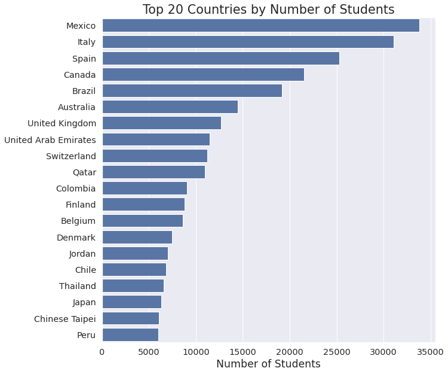

```python
# Get top20 countries
data = df_c['country'].value_counts().head(20)

# Unify the color by storing it into base_color
base_color = sb.color_palette()[0]
# Plot
plt.figure(figsize=[10, 10])
sb.countplot(data=df_c, y='country', order=data.index, color=base_color)
plt.title('Top 20 Countries by Number of Students')
plt.xlabel('Number of Students')
plt.ylabel(None);
```

### Observations

Student from Mexico and Italy lead in term of number of student with more than 30000, followed by Spain Canda Brazil Australia United Kingdom.

### Question

Wich countries best perform in Pisa test 2012?

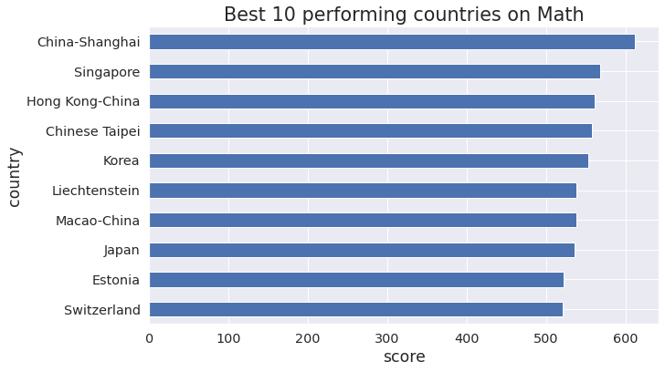

```python
#Get the best performing countries in Math
df_c_m=df_c.groupby('country').mean().sort_values(by='Math',ascending=True)['Math'].tail(10).plot(kind='barh')
plt.xlabel('score')
plt.title('Best 10 performing countries on Math')
```

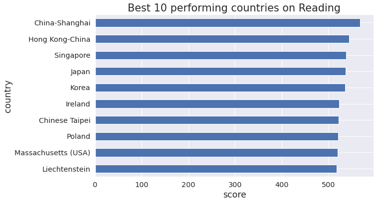

```python
#Get the best performing countries in Reading
df_c_r=df_c.groupby('country').mean().sort_values(by='Reading',ascending=True)['Reading'].tail(10).plot(kind='barh')
plt.xlabel('score')
plt.title('Best 10 performing countries on Reading')
```

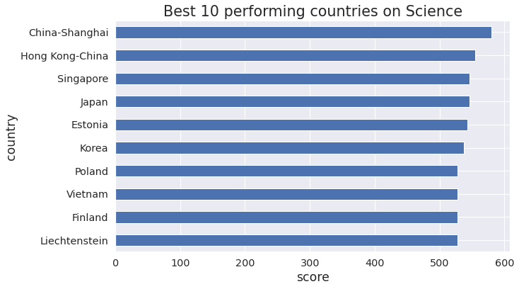

```python
#Get the best performing countries in Science
df_c_r=df_c.groupby('country').mean().sort_values(by='Science',ascending=True)['Science'].tail(10).plot(kind='barh')
plt.xlabel('score')
plt.title('Best 10 performing countries on Science')
```

### Observations

As we can see Shanghai leads the three test foloowed by Asiatic countries fellowed in second place by Singapore and Hong kong.

### Question

What is the best performance contry in Math reading and sciecne score with with most pourcentage of outperforming student

```python
#create a function to get the best countries and find the percentage of outperfom student
def best_score_countries(score):
    # Create a copy
    df_copy = df_c.copy()

    # Take upper quartile threshold
    thr = df_copy[score].max() * 0.75

    # Create outperform property
    df_copy['outperform'] = df_copy[score] > thr

    # Find percentage of outperform students in countries
    dep = df_copy.groupby('country').outperform.mean().mul(100)

    # Plot
    dep.sort_values().tail(10).plot(kind='barh')
    plt.xlim(0, dep.max() + 10)
    plt.title(score)
    plt.xlabel(None)
    plt.ylabel(None)

    # Write the total number after the bar
    indexes, labels = plt.yticks()
    for index, label in zip(indexes, labels):
        val = dep[label.get_text()]
        plt.text(y=index, x=val, s='{:.1f}%'.format(val), va='center')

    #remove x-ticks
    plt.tick_params(axis='x',
                    which='both',
                    bottom=False,
                    top=False,
                    labelbottom=False)
```

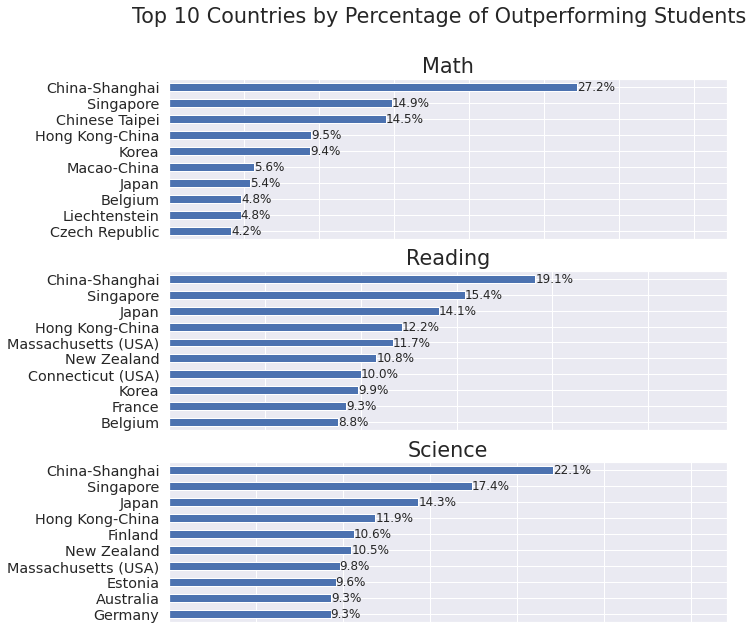

```python
plt.figure(figsize=[10, 10])
plt.suptitle('Top 10 Countries by Percentage of Outperforming Students',
             size='xx-large')

# Plot Math
plt.subplot(3, 1, 1)
best_score_countries('Math')

# Plot Reading
plt.subplot(3, 1, 2)
best_score_countries('Reading')

# Plot Science
plt.subplot(3, 1, 3)
best_score_countries('Science')
```

### Observation

Not only we have here a trend the top performer countery are Asiatic country with the top of class Shanghai with 27% outperforming in math , 19% in reading and 22 in sciecne, followed closely by Singapore.

### Question

What is the proportion of Male and Female student?

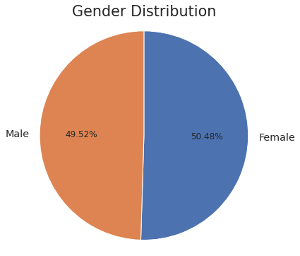

```python
#create pie chart
gender_counts = df_c.Gender.value_counts()
plt.pie(gender_counts, labels = gender_counts.index, startangle = 90, counterclock = False, autopct='%1.2f%%');
plt.axis('square');
plt.title('Gender Distribution')
```

### Observations

Both gender were equaly represented, as expected from a representative demogtraphic sample.

### Question

How much students come from OECD and Non-OECD Countrie?

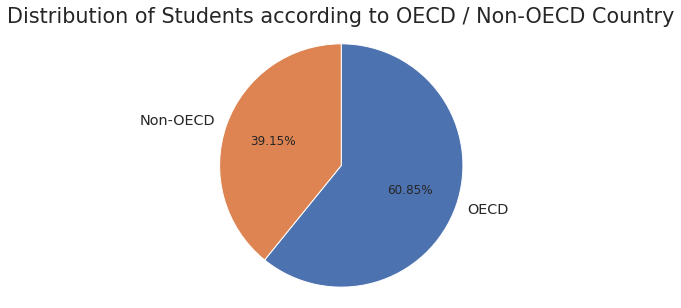

```python
labels = ['OECD', 'Non-OECD']
plt.figure(figsize=[8, 5])
plt.pie(df_c['OECD_country'].value_counts(), labels=labels, autopct='%.2f%%', startangle=90, counterclock=False, )
plt.axis('square')
plt.title('Distribution of Students according to OECD / Non-OECD Country')
```

### Observations

60.85% of student come from OECD, countries with high-income economies with a very high Human Development Index (HDI) and are regarded as developed countries.

### Question

Whais is the math score distibution

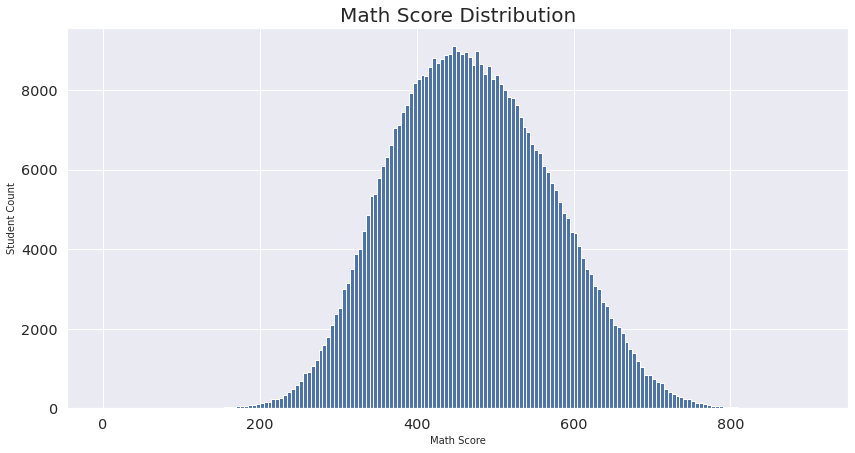

```python
math_bins = np.arange(0, df_c['Math'].max() + 5, 5)
plt.figure(figsize = [14, 7])

plt.hist(data = df_c, x = 'Math', bins = math_bins);
plt.title('Math Score Distribution', size = 20)
plt.xlabel('Math Score', size = 10)
plt.ylabel('Student Count', size = 10);
```

### Observations

The math score looks normally distibuted with the mean roughly between 400 and 500

### Question

Whais is the reading score distibution?

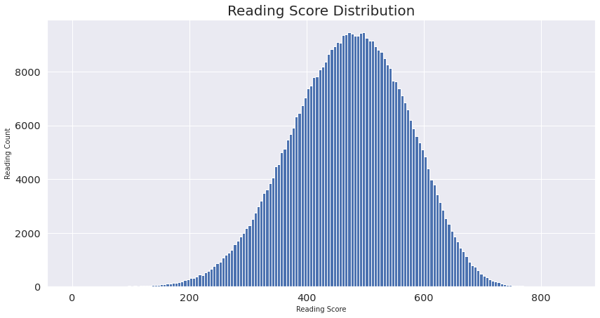

```python
reading_bins = np.arange(0, df_c['Reading'].max() + 5, 5)
plt.figure(figsize = [14, 7])

plt.hist(data = df_c, x = 'Reading', bins = reading_bins);
plt.title('Reading Score Distribution', size = 20)
plt.xlabel('Reading Score', size = 10)
plt.ylabel('Reading Count', size = 10);
```

### Observations

The Reading score looks normally distibuted with the mean roughly between 450 and 500

### Question

Whais is the science distibution?

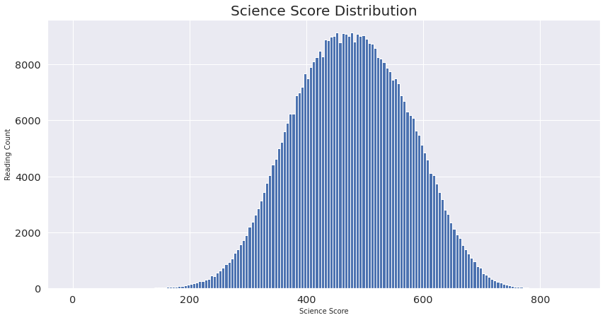

```python
science_bins = np.arange(0, df_c['Science'].max() + 5, 5)
plt.figure(figsize = [14, 7])

plt.hist(data = df_c, x = 'Science', bins =science_bins);
plt.title('Science Score Distribution', size = 20)
plt.xlabel('Science Score', size = 10)
plt.ylabel('Reading Count', size = 10);
```

### Question

How mother and father, job and schooln is distrubute

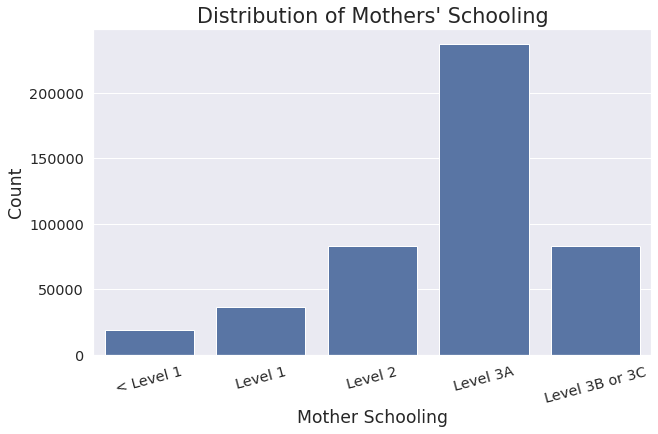

```python
# Plot : Bar chart of the mothers' schooling

# Unify the color by storing it into base_color
base_color = sb.color_palette()[0]

sb.countplot(data = df_c, x = 'Mother_Schooling', color = base_color);

# Rotate the x-axis ticks so that they don't overlap
plt.xticks(rotation = 15)

# Set the plot's title and labels
plt.title("Distribution of Mothers' Schooling")
plt.xlabel("Mother Schooling")
plt.ylabel('Count');
```

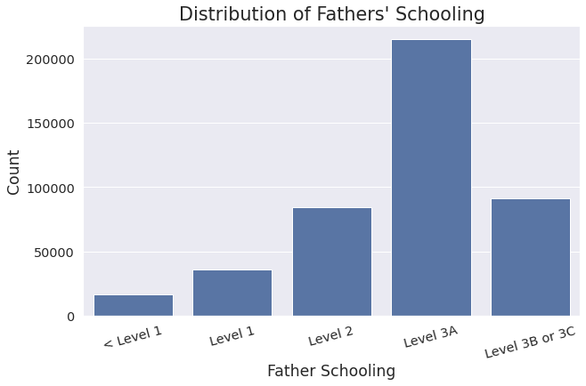

```python
# Plot : Bar chart of the fathers' schooling

sb.countplot(data = df_c, x = 'Father_Schooling', color = base_color);

# Rotate the x-axis ticks so that they don't overlap
plt.xticks(rotation = 15)

# Set the plot's title and labels
plt.title("Distribution of Fathers' Schooling")
plt.xlabel("Father Schooling")
plt.ylabel('Count');
```

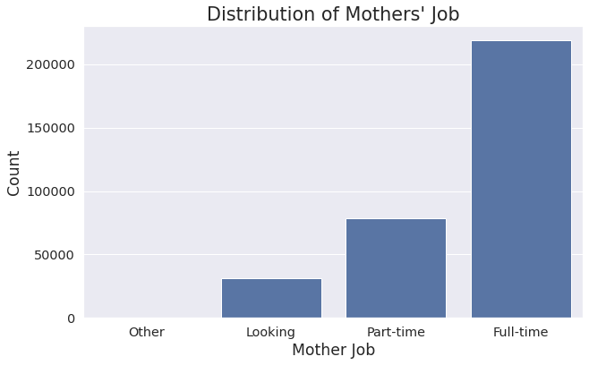

```python
# Plot : Bar chart of the mothers' job

sb.countplot(data = df_c, x = 'Mother_Job', color = base_color);

# Set the plot's title and labels
plt.title("Distribution of Mothers' Job")
plt.xlabel("Mother Job")
plt.ylabel('Count');
```

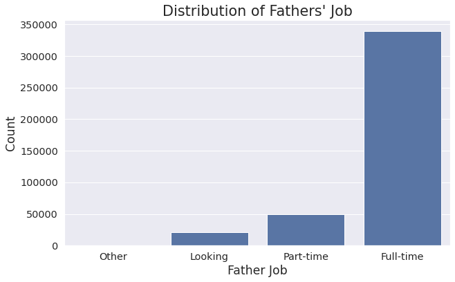

```python
# Plot : Bar chart of the fathers' job

sb.countplot(data = df_c, x = 'Father_Job', color = base_color);

# Set the plot's title and labels
plt.title("Distribution of Fathers' Job")
plt.xlabel("Father Job")
plt.ylabel('Count');
```

### Observation

Student parent had for most of them a full time job and and study level 3A.

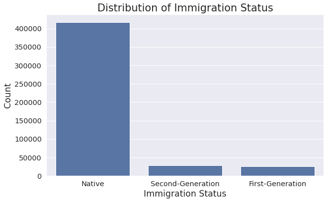

```python
# Plot : Bar chart of the immigration status

# Get the descending order of the Immigration Status column
gen_order = df_c['Immigration_status'].value_counts().index

sb.countplot(data = df_c, x = 'Immigration_status', color = base_color, order = gen_order);

# Set the plot's title and labels
plt.title("Distribution of Immigration Status")
plt.xlabel("Immigration Status")
plt.ylabel('Count');
```

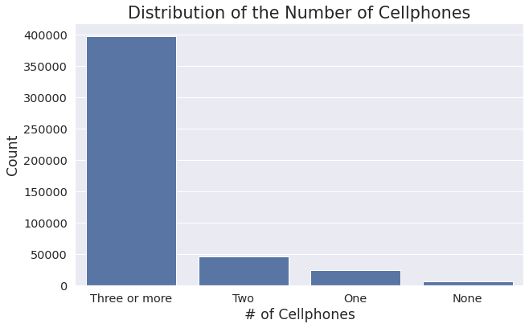

```python
# Plot : Bar chart of the number of cellphones

# Get the descending order of the No_Cellphones column
gen_order = df_c['cellular_phones'].value_counts().index

sb.countplot(data = df_c, x = 'cellular_phones', color = base_color, order = gen_order);

# Set the plot's title and labels
plt.title("Distribution of the Number of Cellphones")
plt.xlabel("# of Cellphones")
plt.ylabel('Count');
```

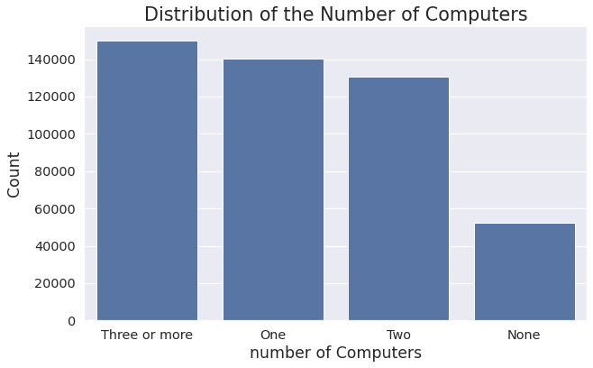

```python
# Plot : Bar chart of the number of computers

# Get the descending order of the No_Computers column
gen_order = df_c['computers'].value_counts().index

sb.countplot(data = df_c, x = 'computers', color=base_color, order=gen_order);

# Set the plot's title and labels
plt.title("Distribution of the Number of Computers")
plt.xlabel("number of Computers")
plt.ylabel('Count');
```

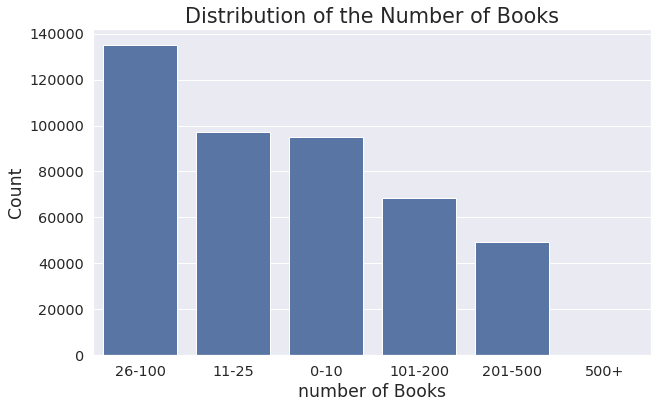

```python
# Plot : Bar chart of the number of books

# Get the descending order of the No_Books column
gen_order = df_c['books_at_home'].value_counts().index

sb.countplot(data = df_c, x = 'books_at_home', color=base_color, order=gen_order);

# Set the plot's title and labels
plt.title("Distribution of the Number of Books")
plt.xlabel("number of Books")
plt.ylabel('Count');
```

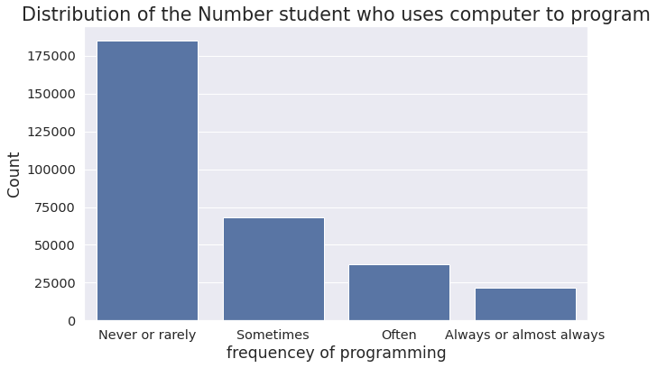

```python
# Plot : Bar chart of computer_programming

# Get the descending order of the No_Books column
gen_order = df_c['computer_programming'].value_counts().index

sb.countplot(data = df_c, x = 'computer_programming', color=base_color, order=gen_order);

# Set the plot's title and labels
plt.title("Distribution of the Number student who uses computer to program")
plt.xlabel("frequencey of programming")
plt.ylabel('Count');
```

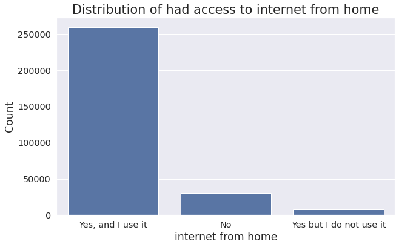

```python
# Plot : Bar chart of At_Home_Internet_connection

# Get the descending order of the No_Books column
gen_order = df_c['At_Home_Internet_connection'].value_counts().index

sb.countplot(data = df_c, x = 'At_Home_Internet_connection', color=base_color, order=gen_order);

# Set the plot's title and labels
plt.title("Distribution of had access to internet from home")
plt.xlabel("internet from home")
plt.ylabel('Count');
```

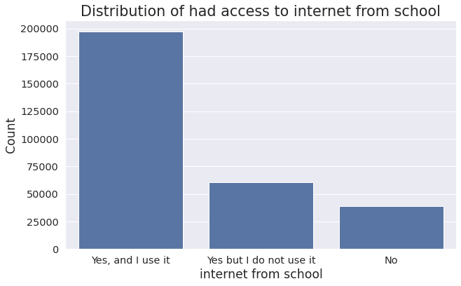

```python
# Plot : Bar chart of At_school_Internet_connection

# Get the descending order of the No_Books column
gen_order = df_c['At_school_Internet_connection'].value_counts().index

sb.countplot(data = df_c, x = 'At_school_Internet_connection', color=base_color, order=gen_order);

# Set the plot's title and labels
plt.title("Distribution of had access to internet from school")
plt.xlabel("internet from school")
plt.ylabel('Count');
```

```python
df_c.Family_wealth.describe()
```

```
count    479597.00000
mean         -0.33701
std           1.21530
min          -6.65000
25%          -1.04000
50%          -0.30000
75%           0.43000
max           3.25000
Name: Family_wealth, dtype: float64
```

### Question

Let's look how Wealth Index is distributed.

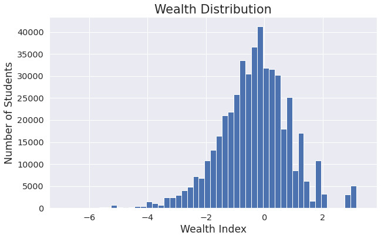

```python
# Create appropriate bins
binsize = 0.2
bins = np.arange(df_c['Family_wealth'].min()-binsize, df_c['Family_wealth'].max()+binsize, binsize)

# Plot
plt.hist(data = df_c, x = 'Family_wealth', bins = bins)
plt.title('Wealth Distribution')
plt.ylabel('Number of Students')
plt.xlabel('Wealth Index')
```

## Bivariate Exploration

> In this section, investigate relationships between pairs of variables in your data. Make sure the variables that you cover here have been introduced in some fashion in the previous section (univariate exploration).

### Question

How well Female do in Math in comparaison with Male student?

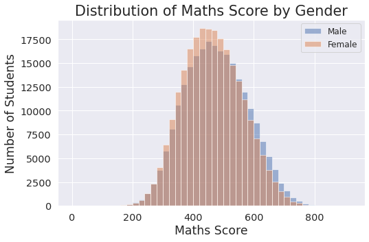

```python
# Histogram for both males and females' maths scores
binsize = 20
bins = np.arange(0, df_c['Math'].max()+binsize, binsize)

plt.figure(figsize=[8, 5])
plt.hist(data=df_c[df_c['Gender']=='Male'], x='Math', bins = bins, label='Male', alpha=0.5)
plt.hist(data=df_c[df_c['Gender']=='Female'], x='Math', bins = bins, label='Female', alpha=0.5)
plt.title('Distribution of Maths Score by Gender')
plt.xlabel('Maths Score')
plt.ylabel('Number of Students')
plt.legend()
plt.show()
```

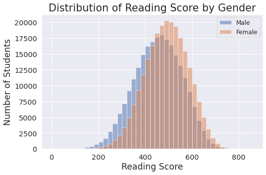

```python
# Histogram for both males and females' reading scores
binsize = 20
bins = np.arange(0, df_c['Reading'].max()+binsize, binsize)

plt.figure(figsize=[8, 5])
plt.hist(data=df_c[df_c['Gender']=='Male'], x='Reading', bins = bins, label='Male', alpha=0.5)
plt.hist(data=df_c[df_c['Gender']=='Female'], x='Reading', bins = bins, label='Female', alpha=0.5)
plt.title('Distribution of Reading Score by Gender')
plt.xlabel('Reading Score')
plt.ylabel('Number of Students')
plt.legend()
plt.show()
```

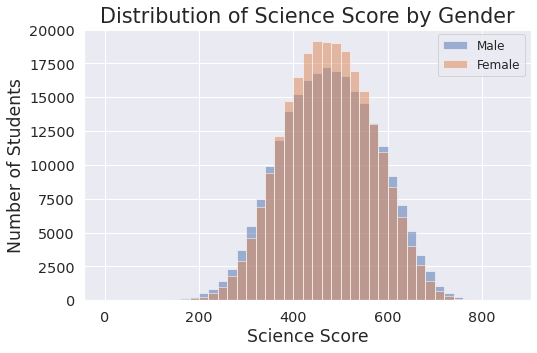

```python
# Histogram for both males and females Science scores
binsize = 20
bins = np.arange(0, df_c['Science'].max()+binsize, binsize)

plt.figure(figsize=[8, 5])
plt.hist(data=df_c[df_c['Gender']=='Male'], x='Science', bins = bins, label='Male', alpha=0.5)
plt.hist(data=df_c[df_c['Gender']=='Female'], x='Science', bins = bins, label='Female', alpha=0.5)
plt.title('Distribution of Science Score by Gender')
plt.xlabel('Science Score')
plt.ylabel('Number of Students')
plt.legend()
plt.show()
```

### Question

Gender and number of computer

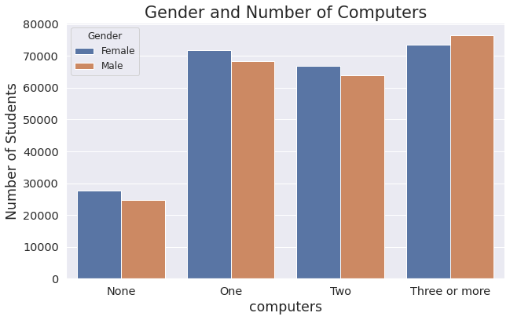

```python
sb.countplot(data = df_c, x = 'computers', hue = 'Gender')
plt.ylabel('Number of Students')
plt.title('Gender and Number of Computers');
```

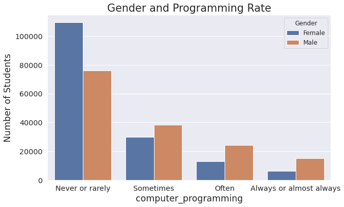

```python
sb.countplot(data = df_c, x = 'computer_programming', hue = 'Gender')
plt.ylabel('Number of Students')
plt.title('Gender and Programming Rate')
```

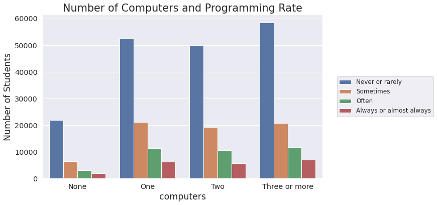

```python
ax = sb.countplot(data = df_c, x = 'computers', hue = 'computer_programming')
plt.ylabel('Number of Students')
plt.title('Number of Computers and Programming Rate')

# Place legend outside of the graph
ax.legend(bbox_to_anchor=(1.04,0.5), loc="center left");
```

### Question

Is ther a difference betwwen OECD and non OECD countries scores?

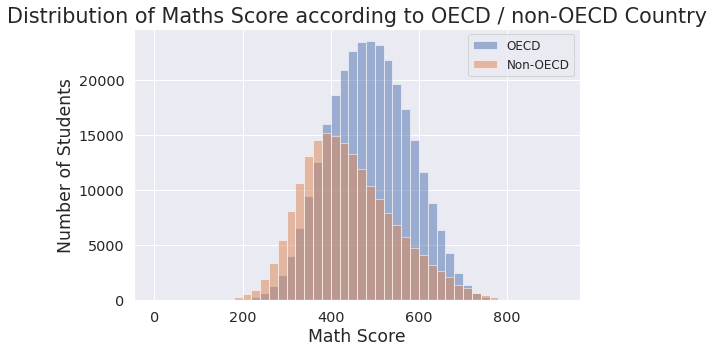

```python
# Histogram for OCDE  and non_OCDE  maths scores
binsize = 20
bins = np.arange(0, df_c['Math'].max()+binsize, binsize)

plt.figure(figsize=[8, 5])
plt.hist(data=df_c[df_c['OECD_country']=='OECD'], x='Math', bins = bins, label='OECD', alpha=0.5)
plt.hist(data=df_c[df_c['OECD_country']=='Non-OECD'], x='Math', bins = bins, label='Non-OECD', alpha=0.5)
plt.title('Distribution of Maths Score according to OECD / non-OECD Country')
plt.xlabel('Math Score')
plt.ylabel('Number of Students')
plt.legend()
plt.show()
```

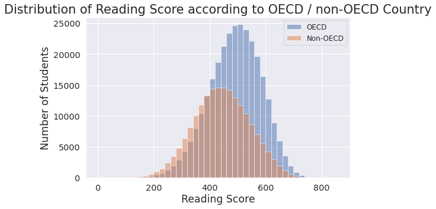

```python
# Histogram for OCDE  and non_OCDE  Reading scores
binsize = 20
bins = np.arange(0, df_c['Reading'].max()+binsize, binsize)

plt.figure(figsize=[8, 5])
plt.hist(data=df_c[df_c['OECD_country']=='OECD'], x='Reading', bins = bins, label='OECD', alpha=0.5)
plt.hist(data=df_c[df_c['OECD_country']=='Non-OECD'], x='Reading', bins = bins, label='Non-OECD', alpha=0.5)
plt.title('Distribution of Reading Score according to OECD / non-OECD Country')
plt.xlabel('Reading Score')
plt.ylabel('Number of Students')
plt.legend()
plt.show()
```

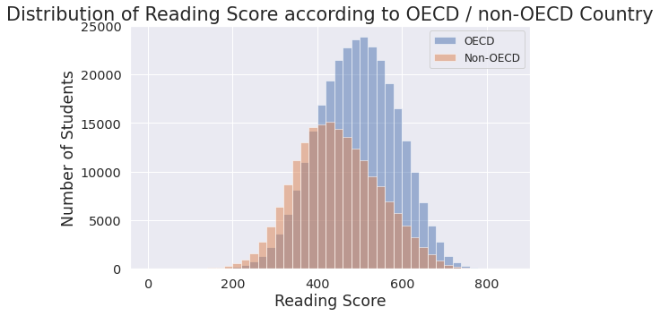

```python
# Histogram for OCDE  and non_OCDE Science scores
binsize = 20
bins = np.arange(0, df_c['Science'].max()+binsize, binsize)

plt.figure(figsize=[8, 5])
plt.hist(data=df_c[df_c['OECD_country']=='OECD'], x='Science', bins = bins, label='OECD', alpha=0.5)
plt.hist(data=df_c[df_c['OECD_country']=='Non-OECD'], x='Science', bins = bins, label='Non-OECD', alpha=0.5)
plt.title('Distribution of Reading Score according to OECD / non-OECD Country')
plt.xlabel('Reading Score')
plt.ylabel('Number of Students')
plt.legend()
plt.show()
```

### Observation

There is clear dominance for OECD countries specially in median score and the gap reduce for outperformer, there is probably due the a better educatif system